# Forecasting Monthly Overnight Stays in Portuguese Tourist Accommodation

## 3.5 Model selection

```r
ic_table <- rbind(
  M1 = M1.fit$ICs,
  M2 = M2.fit$ICs,
  M3 = M3.fit$ICs,
  M4 = M4.fit$ICs,
  M5 = M5.fit$ICs,
  M6 = M6.fit$ICs,
  M7 = M7.fit$ICs
)
kable(ic_table, digits = 4,
      caption = "Table 2. Information criteria for the seven candidate SARIMA models.")
```

Table 2. Information criteria for the seven candidate SARIMA models.

|  | AIC | AICc | BIC |
| --- | --- | --- | --- |
| M1 | -3.271 | -3.271 | -3.224 |
| M2 | -3.202 | -3.201 | -3.155 |
| M3 | -3.266 | -3.265 | -3.203 |
| M4 | -3.247 | -3.247 | -3.200 |
| M5 | -3.244 | -3.244 | -3.197 |
| M6 | -3.264 | -3.263 | -3.185 |
| M7 | -3.264 | -3.263 | -3.185 |

```r
M1.arima <- Arima(log_train, order = c(0, 1, 1), seasonal = c(0, 1, 1))
M1.arima
```

```
## Series: log_train
## ARIMA(0,1,1)(0,1,1)[12]
##
## Coefficients:
##         ma1    sma1
##       -0.51  -0.488
## s.e.   0.07   0.067
##
## sigma^2 = 0.00216:  log likelihood = 354.6
## AIC=-703.2   AICc=-703.1   BIC=-693.1
```

We re-fit M1 with `Arima()` (same estimates as `sarima()`) so that we can produce forecast objects in the next subsection.

```r
M7.arima <- Arima(log_train, order = c(1, 1, 1), seasonal = c(1, 1, 1))
M7.arima
```

```
## Series: log_train
## ARIMA(1,1,1)(1,1,1)[12]
##
## Coefficients:
##          ar1     ma1    sar1    sma1
##       -0.153  -0.377  -0.171  -0.348
## s.e.   0.150   0.148   0.131   0.131
##
## sigma^2 = 0.00216:  log likelihood = 355.8
## AIC=-701.6   AICc=-701.4   BIC=-684.8
```

We refit M7 the same way, so the forecasting strategies below can be applied to both models with identical machinery.

### 3.5.1 Residual diagnostic comparison: M1 vs M7

The motivation for testing M7 is residual autocorrelation, not information criteria. We therefore compare ACF/PACF of the in-sample residuals directly.

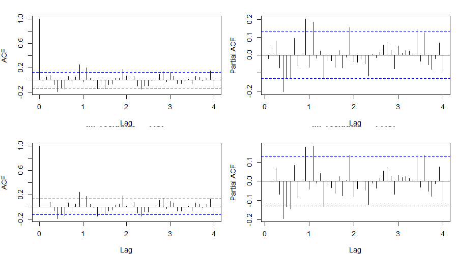

Figure 17b. Residual ACF and PACF for M1 (top two panels) and M7 (bottom two panels), lags up to 48. The relevant question is whether M7 brings the spikes inside the bounds at the lags where M1 leaves structure.

```r
par(mfrow = c(2, 2), mar = c(4, 4, 2, 1))
acf(residuals(M1.arima),  lag.max = 48, main = "M1 residuals — ACF")
pacf(residuals(M1.arima), lag.max = 48, main = "M1 residuals — PACF")
acf(residuals(M7.arima),  lag.max = 48, main = "M7 residuals — ACF")
pacf(residuals(M7.arima), lag.max = 48, main = "M7 residuals — PACF")
```

```r
par(mfrow = c(1, 1))
```

```r
lb_lags <- c(6, 12, 18, 24, 36)
lb_M1 <- sapply(lb_lags, function(L)
  Box.test(residuals(M1.arima), lag = L, type = "Ljung-Box",
           fitdf = length(M1.arima$coef))$p.value)
lb_M7 <- sapply(lb_lags, function(L)
  Box.test(residuals(M7.arima), lag = L, type = "Ljung-Box",
           fitdf = length(M7.arima$coef))$p.value)
lb_tab <- data.frame(Lag = lb_lags,
                     `M1 p-value` = round(lb_M1, 4),
                     `M7 p-value` = round(lb_M7, 4),
                     check.names = FALSE)
kable(lb_tab,
      caption = "Table 2b. Ljung-Box test p-values on residuals at selected lags. Larger p-values (> 0.05) are consistent with white-noise residuals.")
```

Table 2b. Ljung-Box test p-values on residuals at selected lags. Larger p-values (> 0.05) are consistent with white-noise residuals.

| Lag | M1 p-value | M7 p-value |
| --- | --- | --- |
| 6 | 0.0044 | 0.0006 |
| 12 | 0.0000 | 0.0000 |
| 18 | 0.0000 | 0.0000 |
| 24 | 0.0000 | 0.0000 |
| 36 | 0.0000 | 0.0000 |

## 3.6 Forecasting strategies

```r
ts_to_df <- function(x) {
  data.frame(
    time  = as.Date(as.yearmon(time(x))),
    value = as.numeric(x)
  )
}
df_to_ts <- function(df) {
  ts(df$value, frequency = 12,
     start = c(year(df$time[1]), month(df$time[1])))
}

adj_df <- ts_to_df(adjusted_ts)
```

### 3.6.1 Strategy 1 — fixed training, 12-step ahead

```r
# M1
fc_S1 <- forecast(M1.arima, h = 12, level = 95)
S1_mean_log  <- fc_S1$mean
S1_mean_orig <- exp(S1_mean_log)
S1_lo_orig   <- exp(fc_S1$lower[, 1])
S1_hi_orig   <- exp(fc_S1$upper[, 1])

# M7
fc_S1_M7 <- forecast(M7.arima, h = 12, level = 95)
S1_M7_mean_log  <- fc_S1_M7$mean
S1_M7_mean_orig <- exp(S1_M7_mean_log)
S1_M7_lo_orig   <- exp(fc_S1_M7$lower[, 1])
S1_M7_hi_orig   <- exp(fc_S1_M7$upper[, 1])
```

One model is estimated on the full training data and used to forecast all 12 months ahead. Forecast uncertainty grows with horizon. Both M1 and M7 are evaluated.

### 3.6.2 Strategy 2 — fixed model, 1-step interaction

```r
# M1
out <- data.frame()
for (i in 1:12) {
  sub <- adj_df %>%
    filter(time <= as.Date("2024-12-01") %m+% months(i))
  ts_sel <- ts(log(sub$value), frequency = 12,
               end = c(year(tail(sub$time, 1)),
                       month(tail(sub$time, 1))))
  fit <- Arima(ts_sel, model = M1.arima)
  out <- bind_rows(out, data.frame(
    time  = as.Date("2024-12-01") %m+% months(i),
    value = tail(fitted(fit), 1)
  ))
}
S2_mean_log  <- df_to_ts(out)
S2_mean_orig <- exp(S2_mean_log)

# M7
out <- data.frame()
for (i in 1:12) {
  sub <- adj_df %>%
    filter(time <= as.Date("2024-12-01") %m+% months(i))
  ts_sel <- ts(log(sub$value), frequency = 12,
               end = c(year(tail(sub$time, 1)),
                       month(tail(sub$time, 1))))
  fit <- Arima(ts_sel, model = M7.arima)
  out <- bind_rows(out, data.frame(
    time  = as.Date("2024-12-01") %m+% months(i),
    value = tail(fitted(fit), 1)
  ))
}
S2_M7_mean_log  <- df_to_ts(out)
S2_M7_mean_orig <- exp(S2_M7_mean_log)
```

The estimated model is *not* re-estimated; instead, at each step the training data are extended by one observation and the model is *applied* (parameters fixed) to produce a one-step-ahead fitted value. This tests how each fixed model adapts.

### 3.6.3 Strategy 3 — expanding windows, 1-step ahead

```r
# M1
out <- data.frame()
for (i in 0:11) {
  sub <- adj_df %>%
    filter(time <= as.Date("2024-12-01") %m+% months(i))
  ts_sel <- ts(log(sub$value), frequency = 12,
               end = c(year(tail(sub$time, 1)),
                       month(tail(sub$time, 1))))
  fit <- Arima(ts_sel, order = c(0, 1, 1), seasonal = c(0, 1, 1))
  fct <- forecast(fit, h = 1, level = 95)
  out <- bind_rows(out, data.frame(
    time  = as.Date("2025-01-01") %m+% months(i),
    value = as.numeric(fct$mean),
    lo    = as.numeric(fct$lower[, 1]),
    hi    = as.numeric(fct$upper[, 1])
  ))
}
S3_mean_log  <- df_to_ts(out[, c("time", "value")])
S3_mean_orig <- exp(S3_mean_log)
S3_lo_orig   <- exp(df_to_ts(data.frame(time = out$time, value = out$lo)))
S3_hi_orig   <- exp(df_to_ts(data.frame(time = out$time, value = out$hi)))

# M7
out <- data.frame()
for (i in 0:11) {
  sub <- adj_df %>%
    filter(time <= as.Date("2024-12-01") %m+% months(i))
  ts_sel <- ts(log(sub$value), frequency = 12,
               end = c(year(tail(sub$time, 1)),
                       month(tail(sub$time, 1))))
  fit <- Arima(ts_sel, order = c(1, 1, 1), seasonal = c(1, 1, 1))
  fct <- forecast(fit, h = 1, level = 95)
  out <- bind_rows(out, data.frame(
    time  = as.Date("2025-01-01") %m+% months(i),
    value = as.numeric(fct$mean),
    lo    = as.numeric(fct$lower[, 1]),
    hi    = as.numeric(fct$upper[, 1])
  ))
}
S3_M7_mean_log  <- df_to_ts(out[, c("time", "value")])
S3_M7_mean_orig <- exp(S3_M7_mean_log)
S3_M7_lo_orig   <- exp(df_to_ts(data.frame(time = out$time, value = out$lo)))
S3_M7_hi_orig   <- exp(df_to_ts(data.frame(time = out$time, value = out$hi)))
```

At each step the model is **re-estimated** on a growing training sample and then used to produce a one-step-ahead forecast. This is the strategy that should give the best one-step-ahead accuracy if the specification is correct.

### 3.6.4 Strategy 4 — recursive (sliding) windows, 1-step ahead

```r
# M1
out <- data.frame()
for (i in 0:11) {
  sub <- adj_df %>%
    filter(time >= as.Date("2006-01-01") %m+% months(i) &
           time <= as.Date("2024-12-01") %m+% months(i))
  ts_sel <- ts(log(sub$value), frequency = 12,
               end = c(year(tail(sub$time, 1)),
                       month(tail(sub$time, 1))))
  fit <- Arima(ts_sel, order = c(0, 1, 1), seasonal = c(0, 1, 1))
  fct <- forecast(fit, h = 1, level = 95)
  out <- bind_rows(out, data.frame(
    time  = as.Date("2025-01-01") %m+% months(i),
    value = as.numeric(fct$mean)
  ))
}
S4_mean_log  <- df_to_ts(out)
S4_mean_orig <- exp(S4_mean_log)

# M7
out <- data.frame()
for (i in 0:11) {
  sub <- adj_df %>%
    filter(time >= as.Date("2006-01-01") %m+% months(i) &
           time <= as.Date("2024-12-01") %m+% months(i))
  ts_sel <- ts(log(sub$value), frequency = 12,
               end = c(year(tail(sub$time, 1)),
                       month(tail(sub$time, 1))))
  fit <- Arima(ts_sel, order = c(1, 1, 1), seasonal = c(1, 1, 1))
  fct <- forecast(fit, h = 1, level = 95)
  out <- bind_rows(out, data.frame(
    time  = as.Date("2025-01-01") %m+% months(i),
    value = as.numeric(fct$mean)
  ))
}
S4_M7_mean_log  <- df_to_ts(out)
S4_M7_mean_orig <- exp(S4_M7_mean_log)
```

The window size is fixed (228 observations) and slides forward by one observation at each step. This protects the parameter estimates against the influence of old data.

### 3.6.5 Visual comparison of the four strategies

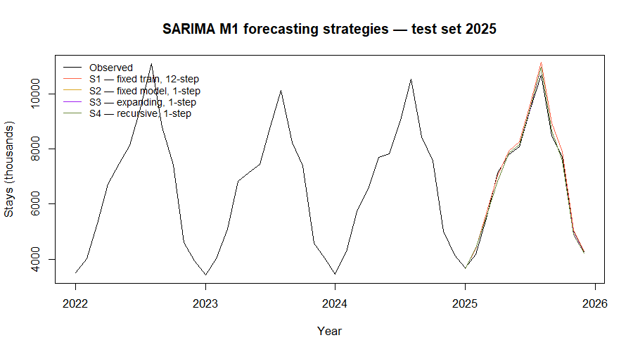

Figure 18. Four SARIMA forecasting strategies for M1, 2025 test set, original scale.

```r
plot(window(adjusted_ts / 1000, start = c(2022, 1)), col = "black", lwd = 1.5,
     ylab = "Stays (thousands)", xlab = "Year",
     main = "SARIMA M1 forecasting strategies — test set 2025")
lines(S1_mean_orig / 1000, col = "tomato",        lwd = 1.5)
lines(S2_mean_orig / 1000, col = "goldenrod",     lwd = 1.5)
lines(S3_mean_orig / 1000, col = "purple",        lwd = 1.5)
lines(S4_mean_orig / 1000, col = "darkolivegreen4", lwd = 1.5)
legend("topleft",
       legend = c("Observed",
                  "S1 — fixed train, 12-step",
                  "S2 — fixed model, 1-step",
                  "S3 — expanding, 1-step",
                  "S4 — recursive, 1-step"),
       col = c("black", "tomato", "goldenrod", "purple", "darkolivegreen4"),
       lwd = 1.5, bty = "n", cex = 0.85)
```

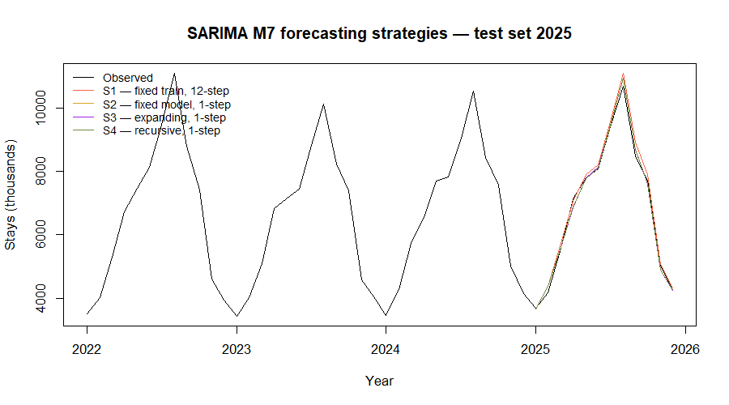

Figure 18b. Four SARIMA forecasting strategies for M7, 2025 test set, original scale.

```r
plot(window(adjusted_ts / 1000, start = c(2022, 1)), col = "black", lwd = 1.5,
     ylab = "Stays (thousands)", xlab = "Year",
     main = "SARIMA M7 forecasting strategies — test set 2025")
lines(S1_M7_mean_orig / 1000, col = "tomato",        lwd = 1.5)
lines(S2_M7_mean_orig / 1000, col = "goldenrod",     lwd = 1.5)
lines(S3_M7_mean_orig / 1000, col = "purple",        lwd = 1.5)
lines(S4_M7_mean_orig / 1000, col = "darkolivegreen4", lwd = 1.5)
legend("topleft",
       legend = c("Observed",
                  "S1 — fixed train, 12-step",
                  "S2 — fixed model, 1-step",
                  "S3 — expanding, 1-step",
                  "S4 — recursive, 1-step"),
       col = c("black", "tomato", "goldenrod", "purple", "darkolivegreen4"),
       lwd = 1.5, bty = "n", cex = 0.85)
```

### 3.6.6 Forecast errors

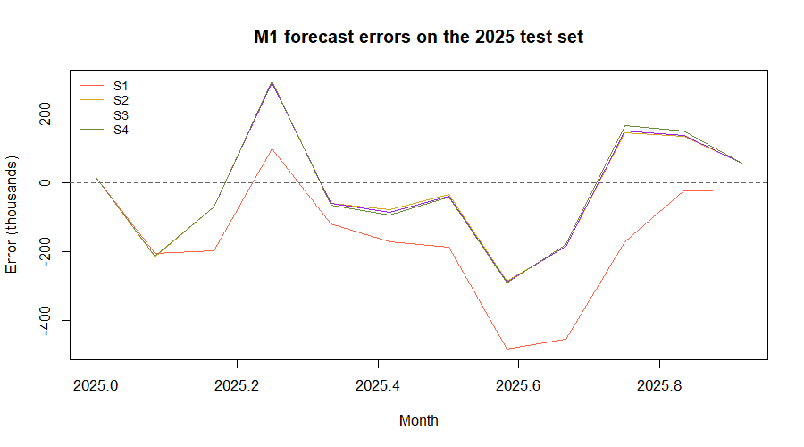

Figure 19. Forecast errors (observed − forecast) for each SARIMA M1 strategy.

```r
err1 <- test_ts - S1_mean_orig
err2 <- test_ts - S2_mean_orig
err3 <- test_ts - S3_mean_orig
err4 <- test_ts - S4_mean_orig

plot(err1 / 1000, col = "tomato", lwd = 1.5, ylab = "Error (thousands)",
     xlab = "Month", main = "M1 forecast errors on the 2025 test set",
     ylim = range(c(err1, err2, err3, err4)) / 1000)
lines(err2 / 1000, col = "goldenrod",       lwd = 1.5)
lines(err3 / 1000, col = "purple",          lwd = 1.5)
lines(err4 / 1000, col = "darkolivegreen4", lwd = 1.5)
abline(h = 0, lty = 2, col = "grey40")
legend("topleft",
       legend = c("S1", "S2", "S3", "S4"),
       col = c("tomato", "goldenrod", "purple", "darkolivegreen4"),
       lwd = 1.5, bty = "n", cex = 0.85)
```

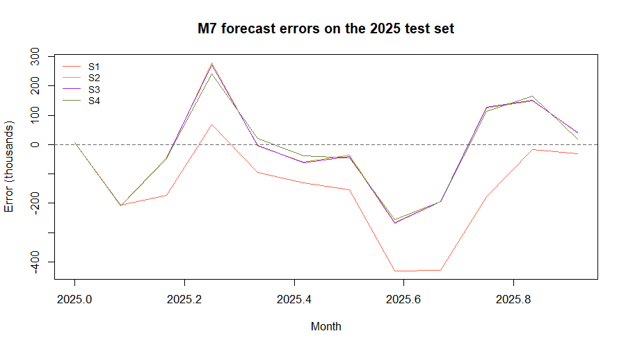

Figure 19b. Forecast errors (observed − forecast) for each SARIMA M7 strategy.

```r
err1_M7 <- test_ts - S1_M7_mean_orig
err2_M7 <- test_ts - S2_M7_mean_orig
err3_M7 <- test_ts - S3_M7_mean_orig
err4_M7 <- test_ts - S4_M7_mean_orig

plot(err1_M7 / 1000, col = "tomato", lwd = 1.5, ylab = "Error (thousands)",
     xlab = "Month", main = "M7 forecast errors on the 2025 test set",
     ylim = range(c(err1_M7, err2_M7, err3_M7, err4_M7)) / 1000)
lines(err2_M7 / 1000, col = "goldenrod",       lwd = 1.5)
lines(err3_M7 / 1000, col = "purple",          lwd = 1.5)
lines(err4_M7 / 1000, col = "darkolivegreen4", lwd = 1.5)
abline(h = 0, lty = 2, col = "grey40")
legend("topleft",
       legend = c("S1", "S2", "S3", "S4"),
       col = c("tomato", "goldenrod", "purple", "darkolivegreen4"),
       lwd = 1.5, bty = "n", cex = 0.85)
```

### 3.6.7 Accuracy table

```r
acc_sarima <- rbind(
  "M1 · S1 — Fixed train, 12-step" = accuracy(S1_mean_orig,    test_ts)[, c("RMSE", "MAE", "MAPE")],
  "M1 · S2 — Fixed model, 1-step"  = accuracy(S2_mean_orig,    test_ts)[, c("RMSE", "MAE", "MAPE")],
  "M1 · S3 — Expanding, 1-step"    = accuracy(S3_mean_orig,    test_ts)[, c("RMSE", "MAE", "MAPE")],
  "M1 · S4 — Recursive, 1-step"    = accuracy(S4_mean_orig,    test_ts)[, c("RMSE", "MAE", "MAPE")],
  "M7 · S1 — Fixed train, 12-step" = accuracy(S1_M7_mean_orig, test_ts)[, c("RMSE", "MAE", "MAPE")],
  "M7 · S2 — Fixed model, 1-step"  = accuracy(S2_M7_mean_orig, test_ts)[, c("RMSE", "MAE", "MAPE")],
  "M7 · S3 — Expanding, 1-step"    = accuracy(S3_M7_mean_orig, test_ts)[, c("RMSE", "MAE", "MAPE")],
  "M7 · S4 — Recursive, 1-step"    = accuracy(S4_M7_mean_orig, test_ts)[, c("RMSE", "MAE", "MAPE")]
)
kable(acc_sarima, digits = 1,
      caption = "Table 3. Accuracy of SARIMA forecasting strategies on the 2025 test set (original scale), for M1 and M7.")
```

Table 3. Accuracy of SARIMA forecasting strategies on the 2025 test set (original scale), for M1 and M7.

|  | RMSE | MAE | MAPE |
| --- | --- | --- | --- |
| M1 · S1 — Fixed train, 12-step | 230463 | 178473 | 2.4 |
| M1 · S2 — Fixed model, 1-step | 159993 | 131194 | 2.0 |
| M1 · S3 — Expanding, 1-step | 160935 | 132712 | 2.0 |
| M1 · S4 — Recursive, 1-step | 163768 | 136004 | 2.0 |
| M7 · S1 — Fixed train, 12-step | 209815 | 159942 | 2.2 |
| M7 · S2 — Fixed model, 1-step | 151593 | 118116 | 1.8 |
| M7 · S3 — Expanding, 1-step | 151226 | 117911 | 1.8 |
| M7 · S4 — Recursive, 1-step | 144783 | 112773 | 1.7 |

As expected, the one-step strategies (S2–S4) are substantially more accurate than the 12-step strategy (S1) for both models. The relevant comparison for the M1-vs-M7 decision is row-by-row within each strategy: if M7 systematically reduces RMSE/MAE/MAPE, the extra parameters are earning their keep; if differences are negligible, the airline model M1 should be preferred on parsimony grounds.

# 4 Forecast comparison

## 4.1 Method-level summary

```r
acc_all <- rbind(
  "HW multiplicative (12-step)"   = accuracy(fc_hw_mult, test_ts)["Test set", c("RMSE", "MAE", "MAPE", "MASE")],
  "STL + ETS (12-step)"           = accuracy(fc_stl,     test_ts)["Test set", c("RMSE", "MAE", "MAPE", "MASE")],
  "SARIMA M1 — Fixed 12-step"     = c(accuracy(S1_mean_orig,    test_ts)[, c("RMSE", "MAE", "MAPE")], MASE = NA),
  "SARIMA M1 — Expanding 1-step"  = c(accuracy(S3_mean_orig,    test_ts)[, c("RMSE", "MAE", "MAPE")], MASE = NA),
  "SARIMA M1 — Recursive 1-step"  = c(accuracy(S4_mean_orig,    test_ts)[, c("RMSE", "MAE", "MAPE")], MASE = NA),
  "SARIMA M7 — Fixed 12-step"     = c(accuracy(S1_M7_mean_orig, test_ts)[, c("RMSE", "MAE", "MAPE")], MASE = NA),
  "SARIMA M7 — Expanding 1-step"  = c(accuracy(S3_M7_mean_orig, test_ts)[, c("RMSE", "MAE", "MAPE")], MASE = NA),
  "SARIMA M7 — Recursive 1-step"  = c(accuracy(S4_M7_mean_orig, test_ts)[, c("RMSE", "MAE", "MAPE")], MASE = NA)
)
kable(acc_all, digits = 1,
      caption = "Table 4. Accuracy of HW multiplicative, STL+ETS, and SARIMA strategies (M1 and M7) on the 2025 test set (original scale).")
```

Table 4. Accuracy of HW multiplicative, STL+ETS, and SARIMA strategies (M1 and M7) on the 2025 test set (original scale).

|  | RMSE | MAE | MAPE | MASE |
| --- | --- | --- | --- | --- |
| HW multiplicative (12-step) | 1234838 | 995349 | 12.7 | 3.5 |
| STL + ETS (12-step) | 1086242 | 814133 | 10.1 | 2.9 |
| SARIMA M1 — Fixed 12-step | 230463 | 178473 | 2.4 | NA |
| SARIMA M1 — Expanding 1-step | 160935 | 132712 | 2.0 | NA |
| SARIMA M1 — Recursive 1-step | 163768 | 136004 | 2.0 | NA |
| SARIMA M7 — Fixed 12-step | 209815 | 159942 | 2.2 | NA |
| SARIMA M7 — Expanding 1-step | 151226 | 117911 | 1.8 | NA |
| SARIMA M7 — Recursive 1-step | 144783 | 112773 | 1.7 | NA |

## 4.2 Month-by-month comparison and 95 % PI coverage

```r
# M1
m1_aux <- sarima.for(log_train, n.ahead = 12,
                     p = 0, d = 1, q = 1, P = 0, D = 1, Q = 1, S = 12,
                     plot = FALSE)
sarima_pt_orig <- exp(m1_aux$pred)
sarima_lo_orig <- exp(m1_aux$pred - 1.96 * m1_aux$se)
sarima_hi_orig <- exp(m1_aux$pred + 1.96 * m1_aux$se)

# M7
m7_aux <- sarima.for(log_train, n.ahead = 12,
                     p = 1, d = 1, q = 1, P = 1, D = 1, Q = 1, S = 12,
                     plot = FALSE)
sarima_m7_pt_orig <- exp(m7_aux$pred)
sarima_m7_lo_orig <- exp(m7_aux$pred - 1.96 * m7_aux$se)
sarima_m7_hi_orig <- exp(m7_aux$pred + 1.96 * m7_aux$se)

monthly_tab <- data.frame(
  Month       = format(as.yearmon(time(test_ts))),
  Observed    = round(as.numeric(test_ts), 0),
  HW_forecast = round(as.numeric(fc_hw_mult$mean), 0),
  HW_PE_pct   = percent(as.numeric((test_ts - fc_hw_mult$mean) / test_ts), accuracy = 0.1),
  HW_in_PI    = between(as.numeric(test_ts),
                        as.numeric(fc_hw_mult$lower[, 1]),
                        as.numeric(fc_hw_mult$upper[, 1])),
  M1_forecast = round(as.numeric(sarima_pt_orig), 0),
  M1_PE_pct   = percent(as.numeric((test_ts - sarima_pt_orig) / test_ts), accuracy = 0.1),
  M1_in_PI    = between(as.numeric(test_ts),
                        as.numeric(sarima_lo_orig),
                        as.numeric(sarima_hi_orig)),
  M7_forecast = round(as.numeric(sarima_m7_pt_orig), 0),
  M7_PE_pct   = percent(as.numeric((test_ts - sarima_m7_pt_orig) / test_ts), accuracy = 0.1),
  M7_in_PI    = between(as.numeric(test_ts),
                        as.numeric(sarima_m7_lo_orig),
                        as.numeric(sarima_m7_hi_orig))
)
kable(monthly_tab,
      align = "lrrrcrrcrrc",
      caption = "Table 5. Month-by-month comparison on the 2025 test set: observed vs HW multiplicative, SARIMA M1, and SARIMA M7 (12-step) point forecasts, percentage errors, and whether the observation lies inside the 95% prediction interval.")
```

Table 5. Month-by-month comparison on the 2025 test set: observed vs HW multiplicative, SARIMA M1, and SARIMA M7 (12-step) point forecasts, percentage errors, and whether the observation lies inside the 95% prediction interval.

| Month | Observed | HW_forecast | HW_PE_pct | HW_in_PI | M1_forecast | M1_PE_pct | M1_in_PI | M7_forecast | M7_PE_pct | M7_in_PI |
| --- | --- | --- | --- | --- | --- | --- | --- | --- | --- | --- |
| jan 2025 | 3669550 | 3858688 | -5.2% | TRUE | 3654048 | 0.4% | TRUE | 3663089 | 0.2% | TRUE |
| fev 2025 | 4173779 | 4674648 | -12.0% | TRUE | 4378338 | -4.9% | TRUE | 4379368 | -4.9% | TRUE |
| mar 2025 | 5563681 | 6319343 | -13.6% | TRUE | 5760951 | -3.5% | TRUE | 5737609 | -3.1% | TRUE |
| abr 2025 | 7130729 | 8030455 | -12.6% | TRUE | 7032188 | 1.4% | TRUE | 7062407 | 1.0% | TRUE |
| mai 2025 | 7804345 | 9028209 | -15.7% | TRUE | 7923883 | -1.5% | TRUE | 7899039 | -1.2% | TRUE |
| jun 2025 | 8082457 | 9577862 | -18.5% | FALSE | 8253162 | -2.1% | TRUE | 8212454 | -1.6% | TRUE |
| jul 2025 | 9417931 | 11167039 | -18.6% | FALSE | 9604799 | -2.0% | TRUE | 9573020 | -1.6% | TRUE |
| ago 2025 | 10688807 | 13084528 | -22.4% | FALSE | 11170511 | -4.5% | TRUE | 11118306 | -4.0% | TRUE |
| set 2025 | 8503904 | 10341373 | -21.6% | FALSE | 8957991 | -5.3% | TRUE | 8932359 | -5.0% | TRUE |
| out 2025 | 7729932 | 8578469 | -11.0% | TRUE | 7900752 | -2.2% | TRUE | 7908155 | -2.3% | TRUE |
| nov 2025 | 5043963 | 5080357 | -0.7% | TRUE | 5065968 | -0.4% | TRUE | 5060954 | -0.3% | TRUE |
| dez 2025 | 4278900 | 4266610 | 0.3% | TRUE | 4298978 | -0.5% | TRUE | 4310954 | -0.7% | TRUE |

```r
stl_in_pi <- between(as.numeric(test_ts),
                     as.numeric(fc_stl$lower[, 1]),
                     as.numeric(fc_stl$upper[, 1]))
```

## 4.3 Visualisation of point forecasts vs observed

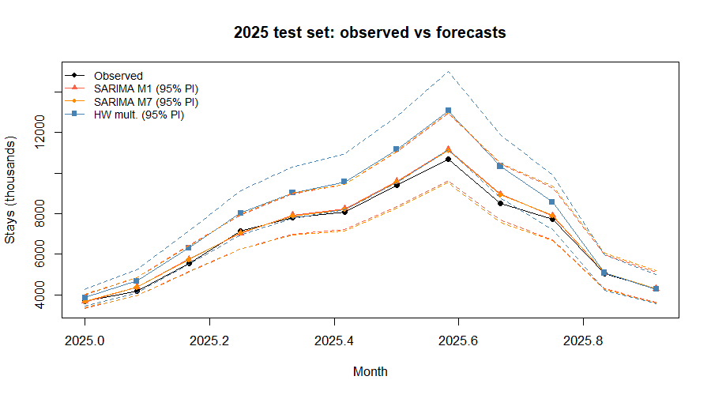

Figure 20. 2025 observed (black) vs SARIMA M1 12-step (red), SARIMA M7 12-step (orange), and HW multiplicative 12-step (blue) point forecasts, with 95% PIs (dashed).

```r
plot(test_ts / 1000, type = "o", pch = 19, lwd = 1.6,
     ylab = "Stays (thousands)", xlab = "Month",
     main = "2025 test set: observed vs forecasts",
     ylim = range(c(test_ts, sarima_pt_orig, sarima_m7_pt_orig, fc_hw_mult$mean,
                    sarima_lo_orig, sarima_hi_orig,
                    sarima_m7_lo_orig, sarima_m7_hi_orig,
                    fc_hw_mult$lower[,1], fc_hw_mult$upper[,1])) / 1000)
lines(sarima_pt_orig    / 1000, col = "tomato",    lwd = 1.6, type = "o", pch = 17)
lines(sarima_m7_pt_orig / 1000, col = "darkorange",lwd = 1.6, type = "o", pch = 18)
lines(fc_hw_mult$mean   / 1000, col = "steelblue", lwd = 1.6, type = "o", pch = 15)
lines(sarima_lo_orig    / 1000, col = "tomato",    lty = 2)
lines(sarima_hi_orig    / 1000, col = "tomato",    lty = 2)
lines(sarima_m7_lo_orig / 1000, col = "darkorange",lty = 2)
lines(sarima_m7_hi_orig / 1000, col = "darkorange",lty = 2)
lines(fc_hw_mult$lower[,1] / 1000, col = "steelblue", lty = 2)
lines(fc_hw_mult$upper[,1] / 1000, col = "steelblue", lty = 2)
legend("topleft",
       legend = c("Observed",
                  "SARIMA M1 (95% PI)",
                  "SARIMA M7 (95% PI)",
                  "HW mult. (95% PI)"),
       col = c("black", "tomato", "darkorange", "steelblue"),
       lwd = 1.6, pch = c(19, 17, 18, 15), bty = "n", cex = 0.85)
```

## 4.4 Which method gives the better forecasts?

The **SARIMA M1** (2.4 % MAPE on the 12-step strategy) beats the 12-step Holt-Winters forecast (around 12.7 % MAPE), and the one-step SARIMA strategies bring MAPE down further to around 2 %.

# 5 Out-of-sample forecasts for 2026

## 5.1 Re-fitting the models

```r
hw_full <- HoltWinters(adjusted_ts, seasonal = "multiplicative")

fc_stl_full <- stlf(adjusted_ts, s.window = "periodic", robust = TRUE,
                    method = "ets", etsmodel = "AAN",
                    lambda = 0, biasadj = TRUE,
                    h = 12, level = 95)

m1_full_log <- Arima(log(adjusted_ts), order = c(0, 1, 1), seasonal = c(0, 1, 1))
m1_full_log
```

```
## Series: log(adjusted_ts)
## ARIMA(0,1,1)(0,1,1)[12]
##
## Coefficients:
##          ma1    sma1
##       -0.513  -0.489
## s.e.   0.068   0.063
##
## sigma^2 = 0.00208:  log likelihood = 378.9
## AIC=-751.9   AICc=-751.8   BIC=-741.6
```

```r
m7_full_log <- Arima(log(adjusted_ts), order = c(1, 1, 1), seasonal = c(1, 1, 1))
m7_full_log
```

```
## Series: log(adjusted_ts)
## ARIMA(1,1,1)(1,1,1)[12]
##
## Coefficients:
##          ar1     ma1    sar1    sma1
##       -0.131  -0.396  -0.197  -0.331
## s.e.   0.154   0.151   0.123   0.123
##
## sigma^2 = 0.00207:  log likelihood = 380.4
## AIC=-750.7   AICc=-750.5   BIC=-733.6
```

## 5.2 Forecasting January – December 2026

```r
fc_hw_2026 <- forecast(hw_full, h = 12, level = 95)

fc_sarima_2026_log <- forecast(m1_full_log, h = 12, level = 95)
fc_sarima_pt  <- exp(fc_sarima_2026_log$mean)
fc_sarima_lo  <- exp(fc_sarima_2026_log$lower[, 1])
fc_sarima_hi  <- exp(fc_sarima_2026_log$upper[, 1])

fc_sarima_m7_2026_log <- forecast(m7_full_log, h = 12, level = 95)
fc_sarima_m7_pt <- exp(fc_sarima_m7_2026_log$mean)
fc_sarima_m7_lo <- exp(fc_sarima_m7_2026_log$lower[, 1])
fc_sarima_m7_hi <- exp(fc_sarima_m7_2026_log$upper[, 1])

oos_tab <- data.frame(
  Month         = format(as.yearmon(time(fc_hw_2026$mean))),
  HW_point      = round(as.numeric(fc_hw_2026$mean), 0),
  HW_lo95       = round(as.numeric(fc_hw_2026$lower[, 1]), 0),
  HW_hi95       = round(as.numeric(fc_hw_2026$upper[, 1]), 0),
  STL_point     = round(as.numeric(fc_stl_full$mean), 0),
  STL_lo95      = round(as.numeric(fc_stl_full$lower[, 1]), 0),
  STL_hi95      = round(as.numeric(fc_stl_full$upper[, 1]), 0),
  M1_point      = round(as.numeric(fc_sarima_pt), 0),
  M1_lo95       = round(as.numeric(fc_sarima_lo), 0),
  M1_hi95       = round(as.numeric(fc_sarima_hi), 0),
  M7_point      = round(as.numeric(fc_sarima_m7_pt), 0),
  M7_lo95       = round(as.numeric(fc_sarima_m7_lo), 0),
  M7_hi95       = round(as.numeric(fc_sarima_m7_hi), 0)
)
kable(oos_tab, align = "lrrrrrrrrrrrr",
      caption = "Table 6. Out-of-sample point forecasts and 95% PIs for 2026 from HW multiplicative, STL+ETS, SARIMA M1, and SARIMA M7.")
```

Table 6. Out-of-sample point forecasts and 95% PIs for 2026 from HW multiplicative, STL+ETS, SARIMA M1, and SARIMA M7.

| Month | HW_point | HW_lo95 | HW_hi95 | STL_point | STL_lo95 | STL_hi95 | M1_point | M1_lo95 | M1_hi95 | M7_point | M7_lo95 | M7_hi95 |
| --- | --- | --- | --- | --- | --- | --- | --- | --- | --- | --- | --- | --- |
| jan 2026 | 3923240 | 3492286 | 4354193 | 3934662 | 3579627 | 4315099 | 3739321 | 3419861 | 4088622 | 3731114 | 3412970 | 4078915 |
| fev 2026 | 4753887 | 4136318 | 5371455 | 4586041 | 4063144 | 5157135 | 4362636 | 3950083 | 4818277 | 4388868 | 3976791 | 4843646 |
| mar 2026 | 6470852 | 5580029 | 7361675 | 6113472 | 5299409 | 7016566 | 5778529 | 5184628 | 6440461 | 5819348 | 5214191 | 6494738 |
| abr 2026 | 8261989 | 7083207 | 9440772 | 7757178 | 6597324 | 9061449 | 7232107 | 6434516 | 8128564 | 7200935 | 6388917 | 8116159 |
| mai 2026 | 9247265 | 7885619 | 10608911 | 8663736 | 7243061 | 10280830 | 8028509 | 7087319 | 9094689 | 8047209 | 7074864 | 9153189 |
| jun 2026 | 9793846 | 8311144 | 11276549 | 9326640 | 7675529 | 11227013 | 8338205 | 7306633 | 9515416 | 8316850 | 7249891 | 9540833 |
| jul 2026 | 11445481 | 9683534 | 13207427 | 11131975 | 9028162 | 13578438 | 9710035 | 8449536 | 11158575 | 9677354 | 8368455 | 11190977 |
| ago 2026 | 13343077 | 11265508 | 15420646 | 13322683 | 10657336 | 16452138 | 11152828 | 9640721 | 12902102 | 11123097 | 9545814 | 12961000 |
| set 2026 | 10601072 | 8908200 | 12293944 | 10305618 | 8137310 | 12874725 | 8907532 | 7651041 | 10370370 | 8890675 | 7574903 | 10434999 |
| out 2026 | 8908480 | 7437360 | 10379601 | 8513537 | 6639536 | 10753167 | 7977935 | 6810879 | 9344968 | 7987790 | 6758655 | 9440458 |
| nov 2026 | 5286212 | 4323782 | 6248641 | 5190681 | 4000428 | 6624911 | 5161175 | 4380356 | 6081180 | 5192598 | 4364449 | 6177886 |
| dez 2026 | 4382498 | 3608943 | 5156052 | 4510113 | 3436589 | 5813918 | 4379137 | 3695606 | 5189092 | 4392340 | 3668246 | 5259366 |

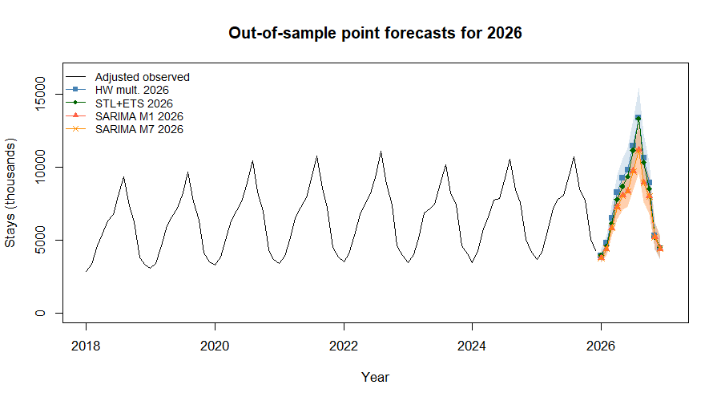

Figure 21. Out-of-sample forecasts for 2026: HW multiplicative (blue), STL+ETS (green), SARIMA M1 (red), and SARIMA M7 (orange). 95% PIs shaded for HW, M1, and M7. Black line shows the adjusted historical series since 2018.

```r
plot(window(adjusted_ts / 1000, start = c(2018, 1)),
     xlim = c(2018, 2027),
     ylim = c(0, max(c(adjusted_ts, fc_hw_2026$upper[,1],
                       fc_sarima_hi, fc_sarima_m7_hi,
                       fc_stl_full$upper[,1])) / 1000),
     ylab = "Stays (thousands)", xlab = "Year",
     main = "Out-of-sample point forecasts for 2026")

t_oos <- as.numeric(time(fc_hw_2026$mean))
polygon(c(t_oos, rev(t_oos)),
        c(as.numeric(fc_hw_2026$lower[,1]),
          rev(as.numeric(fc_hw_2026$upper[,1]))) / 1000,
        col = adjustcolor("steelblue", alpha.f = 0.20), border = NA)
polygon(c(t_oos, rev(t_oos)),
        c(as.numeric(fc_sarima_lo), rev(as.numeric(fc_sarima_hi))) / 1000,
        col = adjustcolor("tomato", alpha.f = 0.20), border = NA)
polygon(c(t_oos, rev(t_oos)),
        c(as.numeric(fc_sarima_m7_lo), rev(as.numeric(fc_sarima_m7_hi))) / 1000,
        col = adjustcolor("darkorange", alpha.f = 0.20), border = NA)

lines(fc_hw_2026$mean / 1000,   col = "steelblue",        lwd = 1.6, type = "o", pch = 15)
lines(t_oos, as.numeric(fc_stl_full$mean) / 1000,
      col = "darkgreen", lwd = 1.6, type = "o", pch = 18)
lines(t_oos, as.numeric(fc_sarima_pt) / 1000,
      col = "tomato",    lwd = 1.6, type = "o", pch = 17)
lines(t_oos, as.numeric(fc_sarima_m7_pt) / 1000,
      col = "darkorange",lwd = 1.6, type = "o", pch = 4)
legend("topleft",
       legend = c("Adjusted observed", "HW mult. 2026", "STL+ETS 2026", "SARIMA M1 2026", "SARIMA M7 2026"),
       col    = c("black",             "steelblue",      "darkgreen",     "tomato",          "darkorange"),
       lwd    = 1.6,
       pch    = c(NA, 15, 18, 17, 4), bty = "n", cex = 0.85)
```